# SPOTVignetteNutshell

- Package version SPOT should be larger than `2.6.0`.

```r
library("SPOT")
packageVersion("SPOT")
```

```
#> [1] '2.11.14'
```

## Introduction

- The performance of modern search heuristics relies crucially on their parameterizations—or, statistically speaking, on their factor settings.
- Finding good parameter settings for an optimization algorithm will be referred to as *tuning*.
- This vignette is an abbreviated version of a the technical report “In a Nutshell-The Sequential Parameter Optimization Toolbox”.
- It illustrates how `spot` can be called.
- The extended version of this vignette is available on [arXiv](https://arxiv.org/abs/1712.04076) and will be updated regularly.

## Sequential Parameter Optimization Examples: How to Call SPOT

### Most simple example: Kriging + LHS + predicted mean optimization (not expected improvement)

- The most simple `spot()` run requires the following parameters:
  - `fun`: objective function, e.g., `funSphere`
  - `lower`: vector of lower limits of the search space, one entry for each dimension. The length of the lower vector determines the problem dimension.
  - `upper`: vector of upper limits of the search space, one entry for each dimension
- A default number of `20` function evalutions is used (`funEvals = 20`).

```r
res <- spot(,funSphere,
            c(-1,-1),
            c(1,1))
cbind(res$xbest, res$ybest)
```

```
#>             [,1]         [,2]         [,3]
#> [1,] -0.01032073 -0.001220482 0.0001080069
```

### With y

```r
set.seed(1)
res <- spot(
  x = matrix(c(0.05), 1, 1),
  fun = funSphere,
  lower = -1,
  upper = 1,
  control = list(
    funEvals = 20,
    model = buildKriging,
    optimizer = optimDE,
    modelControl = list(target = "y")
  )
)
cbind(res$xbest, res$ybest)
```

```
#>               [,1]         [,2]
#> [1,] -3.711794e-05 1.377741e-09
```

### With expected improvement

```r
set.seed(1)
res <- spot(
  x = matrix(c(0.05), 1, 1),
  fun = funSphere,
  lower = -1,
  upper = 1,
  control = list(
    funEvals = 20,
    model = buildKriging,
    optimizer = optimDE,
    modelControl = list(target = "ei")
  )
)
cbind(res$xbest, res$ybest)
```

```
#>               [,1]         [,2]
#> [1,] -8.664214e-06 7.506861e-11
```

### Plot results (basic plot only)

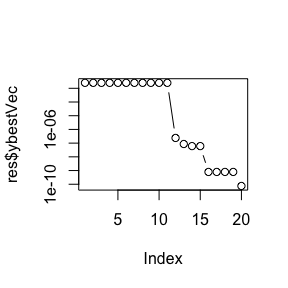

```r
plot(res$ybestVec, log = "y", type="b")
```

### Multi starts on the surrogate

```r
res <- spot(
   x = matrix(c(0.05), 1, 1),
  fun = funSphere,
  lower = -1,
  upper = 1,
  control = list(
    funEvals = 20,
    multiStart = 3,
    model = buildKriging,
    optimizer = optimDE,
    modelControl = list(target = "y"),
    designControl = list(size=10)
  )
)
cbind(res$xbest, res$ybest)
```

```
#>               [,1]         [,2]
#> [1,] -1.188579e-07 1.412721e-14
```

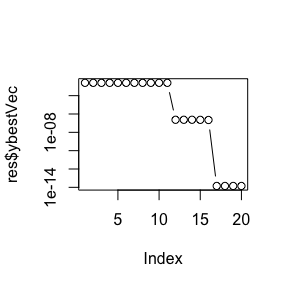

```r
plot(res$ybestVec, log = "y", type="b")
```

### Bayesian Optimization

```r
res <- spot(
  x = NULL,
  fun = funSphere,
  lower = -1,
  upper = 1,
  control = list(
    funEvals = 20,
    multiStart = 2,
    model = buildBO,
    optimizer = optimDE,
    modelControl = list(target = "y"),
    designControl = list(size=10)
  )
)
cbind(res$xbest, res$ybest)
```

[output not shown]

- Left: best y val, right: search on the surrogate

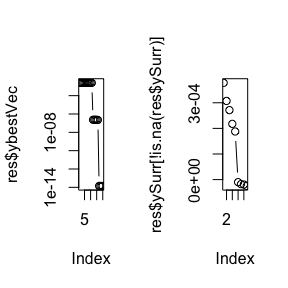

```r
par(mfrow=c(1,2))
plot(res$ybestVec, log = "y", type="b")
plot(res$ySurr[!is.na(res$ySurr)], type="b")
```

```r
par(mfrow=c(1,1))
```

### Replicate (reevaluate the best solution)

- Results can be replicated (which is helpful for noisy objective functions)
- Example below is based on the previous example, which uses a deterministic function, so all replicated values will be identical.
- The result to be reevaluted is specified as the vector `lower`, `upper` has to be set to this value as well (which restricts the search space to one point only).
- The number of replications is specified via `funEvals`.

```r
lower <-res$xbest
resBestReplicated <- spot(x=NULL,
  fun = funSphere,
  lower = lower,
  upper = lower,
  control = list(
    replicateResult = TRUE,
    funEvals = 10
  )
)
cbind(resBestReplicated$x,
      resBestReplicated$y)
```

```
#>                [,1]         [,2]
#>  [1,] -1.188579e-07 1.412721e-14
#>  [2,] -1.188579e-07 1.412721e-14
#>  [3,] -1.188579e-07 1.412721e-14
#>  [4,] -1.188579e-07 1.412721e-14
#>  [5,] -1.188579e-07 1.412721e-14
#>  [6,] -1.188579e-07 1.412721e-14
#>  [7,] -1.188579e-07 1.412721e-14
#>  [8,] -1.188579e-07 1.412721e-14
#>  [9,] -1.188579e-07 1.412721e-14
#> [10,] -1.188579e-07 1.412721e-14
```

## Modify the initial design size

```r
res <- spot(,
            fun = funSphere,
            lower = c(-1,-1),
            upper = c(1,1),
            control = list( #funEvals=4,
                           #verbosity=0
                           #,designControl = list(size = 3)
            )
            )
cbind(res$x, res$y)
```

```
#>              [,1]         [,2]         [,3]
#>  [1,] -0.82703849  0.629569141 1.0803499676
#>  [2,]  0.43543891  0.331775522 0.2996820387
#>  [3,] -0.10133625 -0.162986007 0.0368334749
#>  [4,] -0.71405733 -0.209124373 0.5536108690
#>  [5,] -0.48714723  0.179569698 0.2695577016
#>  [6,]  0.13123246  0.588739411 0.3638360533
#>  [7,]  0.39571081 -0.455261850 0.3638503990
#>  [8,]  0.84643223  0.874071413 1.4804483548
#>  [9,] -0.35183768 -0.843796492 0.8357822734
#> [10,]  0.75936722 -0.797770098 1.2130756996
#> [11,]  0.09865883 -0.097796930 0.0192978047
#> [12,]  0.02070748 -0.103273036 0.0110941196
#> [13,] -0.01032073 -0.001220482 0.0001080069
#> [14,] -0.01867512  0.046198481 0.0024830599
#> [15,]  0.09245131  0.029345694 0.0094084142
#> [16,] -0.11676163  0.070734437 0.0186366381
#> [17,]  0.15592757 -0.015600590 0.0245567870
#> [18,] -0.05542781  0.010803192 0.0031889511
#> [19,] -0.02151719 -0.054124859 0.0033924901
#> [20,]  0.15854184 -0.069685662 0.0299916064
```

### With additional start points:

- Three starting points `x= (0.05, 0.1)`, `x=(-0.1, 0.01)` and `x=(0.01, 0.02)`, which are specified as a `matrix`. Note the `byrow` argument.
- One additional starting point is used `designControl = list(size = 1)`
- The surrogate model is build once, because the budget is set to `funEvals=5`

```r
res <- spot(x = matrix(c(0.05,0.1,
                         -0.1, 0.01,
                         0.01, 0.02),3,2, byrow = TRUE),
            fun = funSphere,
            lower = c(-1,-1),
            upper = c(1,1),
             control = list(funEvals=5,
            designControl = list(size = 1)
            )
            )
cbind(res$x, res$y)
```

```
#>            [,1]       [,2]      [,3]
#> [1,]  0.0500000 0.10000000 0.0125000
#> [2,] -0.1000000 0.01000000 0.0101000
#> [3,]  0.0100000 0.02000000 0.0005000
#> [4,] -0.2557522 0.81641558 0.7319436
#> [5,]  0.8709325 0.06266123 0.7624498
```

- comparison with `optim` (simulated annealing):

```r
fs <- function(x){
  x[1]^2 + x[2]^2}
res <- optim(par=c(0.05, 0,1),
             fn=fs,
             method = "SANN",
             control = list(maxit = 20))
cbind(t(res$par),res$value)
```

```
#>      [,1] [,2] [,3]   [,4]
#> [1,] 0.05    0    1 0.0025
```

### Surrogate-based optimization with optimLBFGSB instead of LHS

```r
res <- spot(x = matrix(c(0.05,0.1),1,2),
            fun = funSphere,
            lower = c(-2,-3),
            upper = c(1,2),
            control=list(funEvals=20,
                         optimizer=optimLBFGSB,
                          modelControl=list(target="ei")
                         )
            )
cbind(res$xbest, res$ybest)
```

```
#>      [,1] [,2]   [,3]
#> [1,] 0.05  0.1 0.0125
```

- Multi start might be useful for LBFGSB:

```r
res <- spot(x = matrix(c(0.05,0.1),1,2),
            fun = funSphere,
            lower = c(-2,-3),
            upper = c(1,2),
            control=list(funEvals=20,
                         optimizer=optimLBFGSB,
                          modelControl=list(target="ei"),
                         multiStart = 2
                         )
            )
cbind(res$xbest, res$ybest)
```

```
#>             [,1]          [,2]         [,3]
#> [1,] -0.01265257 -5.745797e-05 0.0001600907
```

### Random Forest instead of Kriging

```r
res <- spot(,
            funSphere,
            c(-1,-1),
            c(1,1),
            control=list(model=buildRandomForest))
cbind(res$xbest, res$ybest)
```

```
#>              [,1]         [,2]         [,3]
#> [1,] 0.0004720909 -0.006394821 4.111661e-05
```

### LM instead of Kriging

```r
res <- spot(,
            funSphere,
            c(-2,-3),
            c(1,2),
     control=list(model=buildLM)) #lm as surrogate
cbind(res$xbest, res$ybest)
```

```
#>           [,1]      [,2]      [,3]
#> [1,] 0.1531584 0.3294388 0.1319874
```

### Bayesian Optimization

```r
res <- spot(
  x = matrix(c(0.05, 0.1), 1, 2),
  fun = funSphere,
  lower = c(-1, -1),
  upper = c(1, 1),
  control = list(
    funEvals = 20,
    model = buildBO,
    optimizer = optimLBFGSB,
    modelControl = list(target = "ei")
  )
)
cbind(res$xbest, res$ybest)
```

```
#>      [,1] [,2]   [,3]
#> [1,] 0.05  0.1 0.0125
```

```r
res <- spot(,funSphere,c(-2,-3),c(1,2),
   control=list(model=buildLM, optimizer=optimLBFGSB))
res$xbest
```

```
#>           [,1]      [,2]
#> [1,] 0.1531584 0.3294388
```

### Lasso and local optimizer NLOPTR

```r
res <- spot(,funSphere,
            lower = c(-2,-3),
            upper = c(1,2),
             control = list(funEvals=50,
                            model=buildLasso,
                optimizer = optimNLOPTR,
            designControl = list(size = 20)
            ))
res$xbest
```

```
#>            [,1]       [,2]
#> [1,] 0.09877579 -0.1655962
```

### Kriging and local optimizer LBFGSB

```r
res <- spot(,funSphere,c(-2,-3),c(1,2),
   control=list(model=buildKriging, optimizer = optimLBFGSB))
cbind(res$xbest, res$ybest)
```

```
#>             [,1]         [,2]         [,3]
#> [1,] -0.01773916 -0.001142165 0.0003159822
```

### Kriging and local optimizer NLOPTR

```r
res <- spot(,funSphere,c(-2,-3),c(1,2),
     control=list(model=buildKriging, optimizer = optimNLOPTR))
cbind(res$xbest, res$ybest)
```

```
#>             [,1]        [,2]         [,3]
#> [1,] -0.02263374 0.002972108 0.0005211198
```

### Or a different Kriging model:

```r
res <- spot(,funSphere,c(-2,-3),c(1,2),
 control=list(model=buildKrigingDACE, optimizer=optimLBFGSB))
res$xbest
```

```
#>            [,1]        [,2]
#> [1,] 0.09403992 -0.04007123
```

### Transform x values

- `x` values are transformed via `2^x`
- output shows natural and transformed `x` values

```r
# Use transformed input values
set.seed(1)
f2 <- function(x){2^x}
lower <- c(-100, -100)
upper <- c(10, 10)
transformFun <- rep("f2", length(lower))
res <- spot(x=NULL,
            fun=funSphere,
            lower=lower,
            upper=upper,
             control=list(funEvals=20,
                          modelControl=list(target="ei"),
                          optimizer=optimLBFGSB,
                          transformFun=transformFun,
                          verbosity = 0,
                          progress = FALSE,
                          plots = FALSE))
print(cbind(res$x, res$xt, res$y))
```

```
#>              [,1]        [,2]         [,3]         [,4]         [,5]
#>  [1,]  -90.487117  -10.373697 5.763198e-28 7.537129e-04 5.680832e-07
#>  [2,]  -21.050860  -26.752346 4.603198e-07 8.845885e-09 2.119726e-13
#>  [3,]  -50.573494  -53.964230 5.968447e-16 5.690468e-17 3.594617e-31
#>  [4,]  -84.273153  -56.501840 4.278122e-26 9.800567e-18 9.605111e-35
#>  [5,]  -71.793098  -35.123667 2.444129e-22 2.671301e-11 7.135848e-22
#>  [6,]  -37.782215  -12.619332 4.230777e-12 1.589287e-04 2.525834e-08
#>  [7,]  -23.235905  -70.039402 1.012268e-07 8.242125e-22 1.024687e-14
#>  [8,]    1.553773    3.073928 2.935839e+00 8.420627e+00 7.952611e+01
#>  [9,]  -64.351072  -91.408807 4.250078e-20 3.042336e-28 1.806317e-39
#> [10,]   -3.234803  -88.877355 1.062251e-01 1.758936e-27 1.128378e-02
#> [11,] -100.000000  -18.335894 7.888609e-31 3.022359e-06 9.134652e-12
#> [12,] -100.000000  -45.470842 7.888609e-31 2.050749e-14 4.205573e-28
#> [13,] -100.000000  -78.918523 7.888609e-31 1.750481e-24 3.064184e-48
#> [14,] -100.000000  -14.180231 7.888609e-31 5.386729e-05 2.901685e-09
#> [15,]  -54.483350   10.000000 3.970793e-17 1.024000e+03 1.048576e+06
#> [16,]   -9.233011   10.000000 1.661830e-03 1.024000e+03 1.048576e+06
#> [17,]   10.000000  -40.224817 1.024000e+03 7.782579e-13 1.048576e+06
#> [18,]  -91.586630 -100.000000 2.689534e-28 7.888609e-31 7.233657e-56
#> [19,]   10.000000   -2.281238 1.024000e+03 2.057212e-01 1.048576e+06
#> [20,]  -31.756840 -100.000000 2.755743e-10 7.888609e-31 7.594120e-20
```

```r
print(which.min(res$y[, 1, drop = FALSE]))
```

```
#> [1] 18
```

```r
cbind(res$xbest, res$ybest)
```

```
#>           [,1] [,2]         [,3]
#> [1,] -91.58663 -100 7.233657e-56
```

### With noise: (this takes some time)

Note: If `control$OCBA` then `control$replicates` and `control$designControl$replicates` should be larger than one. The parameter `control$OCBABudget` defines how many additional candidate solutions (from `xnew`) should be evaluated. So, the total number of new evaluations is the sum of `control$designControl$replicates` and `control$OCBABudget`.

```r
# noisy objective
fNoise = function(x){funSphere(x) + rnorm(nrow(x))}
res1 <-
  spot(x = NULL,
       fun = fNoise,
       lower = c(-2, -3),
       upper = c(1, 2),
    control = list(funEvals = 40, noise = TRUE, verbosity=0))
# noise with replicated evaluations
res2 <-
  spot(x = NULL,
       fun = fNoise,
       lower = c(-2, -3),
       upper = c(1, 2),
    control = list(
      verbosity=0,
      funEvals = 40,
      noise = TRUE,
      replicates = 2,
      designControl = list(replicates = 2)
    ))
# and with OCBA
res3 <- spot(x = NULL,
       fun = fNoise,
       lower = c(-2, -3),
       upper = c(1, 2),
  control = list(
    verbosity=0,
    funEvals = 40,
    noise = TRUE,
    replicates = 2,
    OCBA = TRUE,
    OCBABudget = 5,
    designControl = list(replicates = 2)
  )
)
# Check results with non-noisy function:
funSphere(res1$xbest)
```

```
#>           [,1]
#> [1,] 0.7806337
```

```r
funSphere(res2$xbest)
```

```
#>           [,1]
#> [1,] 0.3128347
```

```r
funSphere(res3$xbest)
```

```
#>           [,1]
#> [1,] 0.1319874
```

```r
lower <-res3$xbest
resBestReplicated <- spot(
  ,
  fun = fNoise,
  lower = lower,
  upper = lower,
  control = list(
    funEvals = 10,
    replicateResults = TRUE
   )
)
cbind(resBestReplicated$x,
      resBestReplicated$y)
```

```
#>            [,1]      [,2]        [,3]
#>  [1,] 0.1531584 0.3294388 -0.82121574
#>  [2,] 0.1531584 0.3294388  0.53853014
#>  [3,] 0.1531584 0.3294388  2.36124961
#>  [4,] 0.1531584 0.3294388 -1.38250960
#>  [5,] 0.1531584 0.3294388  0.07027999
#>  [6,] 0.1531584 0.3294388 -0.01528338
#>  [7,] 0.1531584 0.3294388  1.67358048
#>  [8,] 0.1531584 0.3294388 -0.84986826
#>  [9,] 0.1531584 0.3294388  0.62856558
#> [10,] 0.1531584 0.3294388  1.82893529
```

### Random number seed handling

The following is for demonstration only, to be used for random number seed handling in case of external noisy target functions.

```r
res1a <- spot(,function(x,seed){set.seed(seed);funSphere(x)+rnorm(nrow(x))},
     c(-2,-3),c(1,2),control=list(funEvals=25,noise=TRUE,seedFun=1))
```

```r
res1b <- spot(,function(x,seed){set.seed(seed);funSphere(x)+rnorm(nrow(x))},
     c(-2,-3),c(1,2),control=list(funEvals=25,noise=TRUE,seedFun=1))
```

```r
res2 <- spot(,function(x,seed){set.seed(seed);funSphere(x)+rnorm(nrow(x))},
     c(-2,-3),c(1,2),control=list(funEvals=25,noise=TRUE,seedFun=2))
```

```r
sprintf("Should be equal: %f = %f. Should be different:  %f", res1a$ybest, res1b$ybest, res2$ybest)
```

```
#> [1] "Should be equal: -0.574866 = -0.574866. Should be different:  -0.807379"
```

### Handling factor variables

Note: factors should be coded as integer values, i.e., 1,2,…,n First, we create a test function with a factor variable:

```r
braninFunctionFactor <- function (x) {
   y <- (x[2]  - 5.1/(4 * pi^2) * (x[1] ^2) + 5/pi * x[1]  - 6)^2 +
     10 * (1 - 1/(8 * pi)) * cos(x[1] ) + 10
   if(x[3]==1)
     y <- y +1
   else if(x[3]==2)
     y <- y -1
   return(y)
}
```

Vectorize the test function.

```r
objFun <- function(x){apply(x,1,braninFunctionFactor)}
```

Run `spot`.

```r
set.seed(1)
res <- spot(fun=objFun,lower=c(-5,0,1),upper=c(10,15,3),
            control=list(model=buildKriging,
                         types= c("numeric","numeric","factor"),
                         optimizer=optimLHD))
 res$xbest
```

```
#>          [,1]     [,2] [,3]
#> [1,] 3.116086 2.166734    3
```

```r
 res$ybest
```

```
#>           [,1]
#> [1,] 0.4174566
```

### High dimensional problem

```r
n <- 10
a <- rep(0,n)
b <- rep(1,n)
```

First, we consider the default `spot` setting with `buildKriging()`.

```r
tic <- proc.time()[3]
res0 <- spot(x=NULL, funSphere, lower = a, upper = b,
             control=list(funEvals=30))
toc <- proc.time()[3]
sprintf("value: %f, time: %f",  res0$ybest, toc-tic)
```

```
#> [1] "value: 1.026498, time: 3.622000"
```

Then, we use the `buildGaussianProcess()` model.

```r
tic <- proc.time()[3]
res1 <-  spot(x=NULL, funSphere, lower = a, upper = b,
             control=list(funEvals=30,
                          model = buildGaussianProcess))
toc <- proc.time()[3]
sprintf("value: %f, time: %f",  res1$ybest, toc-tic)
```

```
#> [1] "value: 0.819676, time: 0.408000"
```

### Run SPOT with logging

```r
## run spot without log
res <- spot(fun = funSphere,
            lower=c(0,0),
            upper=c(100,100)
)
## run spot with log (3-dim "y" output: first is y, last are x val (here 2-dim))
funSphereLog <- function(x){
  cbind(funSphere(x),x)
}
res2 <- spot(fun = funSphereLog,
            lower=c(0,0),
            upper=c(100,100)
)
res$logInfo
```

```
#> [1] NA
```

```r
res2$logInfo
```

```
#>             [,1]       [,2]
#>  [1,]  8.6480755 81.4784571
#>  [2,] 71.7719454 66.5887761
#>  [3,] 44.9331873 41.8506996
#>  [4,] 14.2971337 39.5437814
#>  [5,] 25.6426384 58.9784849
#>  [6,] 56.5616232 79.4369705
#>  [7,] 69.7855406 27.2369075
#>  [8,] 92.3216115 93.7035707
#>  [9,] 32.4081160  7.8101754
#> [10,] 87.9683608 10.1114951
#> [11,]  0.8695938  3.4789743
#> [12,]  6.7788538  7.4840977
#> [13,] 10.5474376  0.9580708
#> [14,]  0.4337100  9.4376420
#> [15,]  1.1522512 14.3301670
#> [16,]  2.2464471  6.1725581
#> [17,]  5.8038975  2.6715535
#> [18,]  4.9227178  8.2127192
#> [19,]  8.8485311 11.1649501
#> [20,]  3.2337531  2.8721535
## re-evaluation of the x-values and comparison with evaluated x-values:
```

```r
funSphere(res2$logInfo) == res$y
```

```
#>       [,1]
#>  [1,] TRUE
#>  [2,] TRUE
#>  [3,] TRUE
#>  [4,] TRUE
#>  [5,] TRUE
#>  [6,] TRUE
#>  [7,] TRUE
#>  [8,] TRUE
#>  [9,] TRUE
#> [10,] TRUE
#> [11,] TRUE
#> [12,] TRUE
#> [13,] TRUE
#> [14,] TRUE
#> [15,] TRUE
#> [16,] TRUE
#> [17,] TRUE
#> [18,] TRUE
#> [19,] TRUE
#> [20,] TRUE
```

## Hybrid optimization

```r
res <- spot(fun = funSphere, lower = c(-5,-5),
                upper = c(5,5),
                control = list(funEvals = 20,
                directOpt = optimNLOPTR,
                directOptControl = list(funEvals = 10)
                ))
str(res)
```

[output not shown]

[output cut: 44 more lines]

[output not shown]

## Handling constraints

- Definitions and constraints

```r
library(babsim.hospital)
n <- 29
reps <- 2
funEvals <- 3*n
size <- 2*n
x0 <- matrix(as.numeric(babsim.hospital::getParaSet(5374)[1,-1]),1,)
bounds <- getBounds()
a <- bounds$lower
b <- bounds$upper
g <- function(x) {
      return(rbind(a[1] - x[1], x[1] - b[1], a[2] - x[2], x[2] - b[2],
                   a[3] - x[3], x[3] - b[3], a[4] - x[4], x[4] - b[4],
                   a[5] - x[5], x[5] - b[5], a[6] - x[6], x[6] - b[6],
                   a[7] - x[7], x[7] - b[7], a[8] - x[8], x[8] - b[8],
                   a[9] - x[9], x[9] - b[9], a[10] - x[10], x[10] - b[10],
                   a[11] - x[11], x[11] - b[11], a[12] - x[12],  x[12] - b[12],
                   a[13] - x[13], x[13] - b[13], a[14] - x[14],  x[14] - b[14],
                   a[15] - x[15], x[15] - b[15], a[16] - x[16],  x[16] - b[16],
                   a[17] - x[17], x[17] - b[17], a[18] - x[18],  x[18] - b[18],
                   a[19] - x[19], x[19] - b[19], a[20] - x[20],  x[20] - b[20],
                   a[21] - x[21], x[21] - b[21], a[22] - x[22],  x[22] - b[22],
                   a[23] - x[23], x[23] - b[23], a[24] - x[24],  x[24] - b[24],
                   a[25] - x[25], x[25] - b[25], a[26] - x[26],  x[26] - b[26],
                   a[27] - x[27], x[27] - b[27], x[15] + x[16] - 1,
                   x[17] + x[18] + x[19] - 1, x[20] + x[21] - 1, x[23] + x[29] - 1)
      )
  }
```

```r
res <- spot(
  x = x0,
  fun = funBaBSimHospital,
  lower = a,
  upper = b,
  verbosity = 0,
  control = list(
    funEvals = 2 * funEvals,
    noise = TRUE,
    designControl = list(# inequalityConstraint = g,
      size = size,
      retries = 1000),
    optimizer = optimNLOPTR,
    optimizerControl = list(
      opts = list(algorithm = "NLOPT_GN_ISRES"),
      eval_g_ineq = g
    ),
    model =  buildKriging,
    plots = FALSE,
    progress = TRUE,
    directOpt = optimNLOPTR,
    directOptControl = list(funEvals = 0),
    eval_g_ineq = g
  )
)
print(res)
```

## GECCO Industrial Challenge 2021

A description of the challenge can be found here: [GECCO Industrial Challenge 2021](https://www.th-koeln.de/informatik-und-ingenieurwissenschaften/gecco-2021-industrial-challenge-call-for-participation_82086.php). In short the goal of the challenge is to find an optimal parameter configuration for the BabSim.Hospital simulator. This is a noisy and complex real-world problem.

### Evaluation Using the Docker Container

In order to be able to execute the necessary code of the GECCO Industrial challenge 2021 you will need to have [Docker](https://docs.docker.com/get-docker/) installed in your machine. On your terminal console an evaluation of the BabSim.Hospital should looks like the command below. This command will automatically download the Docker image with the BabSim.Hospital code in it (may need sudo rights to download). Take care, the formatting of the symbols - and ’ can cause this command not to work on your terminal:

```r
# docker run --rm mrebolle/r-geccoc:Track1 -c 'Rscript objfun.R "6,7,3,3,3,5,3,3,25,17,2,1,0.25,0.05,0.07,0.005,0.07,1e-04,0.08,0.25,0.08,0.5,1e-06,2,1e-06,1e-06,1,2,0.5"'
```

An optimization run with SPOT, using the Docker command call as objective function, can be directly implemented in R as follows:

```r
library(SPOT)

evalFun <- function(candidateSolution){
    evalCommand <- paste0("docker run --rm mrebolle/r-geccoc:Track1 -c ", "'","Rscript objfun.R ")
    parsedCandidate <- paste(candidateSolution, sep=",", collapse = ",")
    return(as.numeric(system(paste0(evalCommand, '"', parsedCandidate, '"', "'"), intern = TRUE)))
}

#The BabSim.Hospital requires 29 parameters. Here we specify the upper and lower bounds
lower <- c(6,7,3,3,3,5,3,3,25,17,2,1,0.25,0.05,0.07,
           0.005,0.07,1e-04,0.08,0.25,0.08,0.5,1e-06,
           2,1e-06,1e-06,1,2,0.5)

upper<- c(14,13,7,9,7,9,5,7,35,25,5,7,2,0.15,0.11,0.02,
          0.13,0.002,0.12,0.35,0.12,0.9,0.01,4,1.1,0.0625,
          2,5,0.75)

wFun <- wrapFunction(evalFun)

n <- 29
reps <- 2
funEvals <- 10*n
size <- 2*n
x0<-matrix(lower,nrow = 1)

res <- spot(x = x0,
  fun = wFun,
  lower = lower,
  upper = upper,
  control = list(
    funEvals = 2 * funEvals,
    noise = TRUE,
    designControl = list(
      size = size,
      retries = 1000),
    optimizer = optimNLOPTR,
    optimizerControl = list(
      opts = list(algorithm = "NLOPT_GN_ISRES")
    ),
    model =  buildKriging,
    plots = TRUE,
    progress = TRUE,
    directOpt = optimNLOPTR,
    directOptControl = list(funEvals = 0)
  )
)
```

### Evaluation Using the babsim.hospital R Package

The optimization of the BabSim.Hospital parameters can also be executed directly using the babsim.hospital package.

The babsim.hospital package can be installed by downloading the source from the Gitlab repository and building the package.

```r
git clone http://owos.gm.fh-koeln.de:8055/bartz/babsim.hospital.git
```

```r
library(SPOT)
library(babsim.hospital)

n <- 29
reps <- 2
funEvals <- 3*n
size <- 2*n
#Get suggested parameter values as initial point in the optimization run
x0 <- matrix(as.numeric(babsim.hospital::getParaSet(5374)[1,-1]),1,)
bounds <- getBounds()
a <- bounds$lower
b <- bounds$upper
g <- function(x) {
      return(rbind(a[1] - x[1], x[1] - b[1], a[2] - x[2], x[2] - b[2],
                   a[3] - x[3], x[3] - b[3], a[4] - x[4], x[4] - b[4],
                   a[5] - x[5], x[5] - b[5], a[6] - x[6], x[6] - b[6],
                   a[7] - x[7], x[7] - b[7], a[8] - x[8], x[8] - b[8],
                   a[9] - x[9], x[9] - b[9], a[10] - x[10], x[10] - b[10],
                   a[11] - x[11], x[11] - b[11], a[12] - x[12],  x[12] - b[12],
                   a[13] - x[13], x[13] - b[13], a[14] - x[14],  x[14] - b[14],
                   a[15] - x[15], x[15] - b[15], a[16] - x[16],  x[16] - b[16],
                   a[17] - x[17], x[17] - b[17], a[18] - x[18],  x[18] - b[18],
                   a[19] - x[19], x[19] - b[19], a[20] - x[20],  x[20] - b[20],
                   a[21] - x[21], x[21] - b[21], a[22] - x[22],  x[22] - b[22],
                   a[23] - x[23], x[23] - b[23], a[24] - x[24],  x[24] - b[24],
                   a[25] - x[25], x[25] - b[25], a[26] - x[26],  x[26] - b[26],
                   a[27] - x[27], x[27] - b[27], x[15] + x[16] - 1,
                   x[17] + x[18] + x[19] - 1, x[20] + x[21] - 1, x[23] + x[29] - 1)
      )
  }
```

```r
wrappedFunBab <- function(x){
  print(SPOT::funBaBSimHospital(x, region = 5374, nCores = 1))
}
res <- spot(
  x = x0,
  fun = wrappedFunBab,
  lower = a,
  upper = b,
  control = list(
    funEvals = 2 * funEvals,
    noise = TRUE,
    designControl = list(
      size = size,
      retries = 1000),
    optimizer = optimNLOPTR,
    optimizerControl = list(
      opts = list(algorithm = "NLOPT_GN_ISRES"),
      eval_g_ineq = g
    ),
    model =  buildKriging,
    plots = FALSE,
    progress = TRUE,
    directOpt = optimNLOPTR,
    directOptControl = list(funEvals = 0),
    eval_g_ineq = g
  )
)
print(res)
```

# Benchmarking

```r
res <- spot(
  x = NULL,
  fun = funGoldsteinPrice,
  lower = rep(0,2),
  upper = rep(1,2),
  control = list(
    funEvals = 20,
    multiStart = 5,
    model = buildKriging,
    optimizer = optimDE,
    modelControl = list(target = "ei"),
    designControl = list(size=10)
  )
)
cbind(res$xbest, res$ybest)
```

```r
### Compare Performance
# rm(list=ls())
library(microbenchmark)
library(SPOT)
set.seed(1)
n <- 3
low = -2
up = 2
a = runif(n, low, 0)
b = runif(n, 0, up)
x0 = a + runif(n)*(b-a)
plot(a, type = "l", ylim=c(up,low))
lines(b)
lines(x0)
x0 = matrix( x0, nrow = 1)

set.seed(1)
  perf1 <- spot(x= x0, funSphere, a, b, control=list(time=list(maxTime = 0.25), funEvals=10*n, plots=FALSE,
                                                     model = buildKriging, optimizer=optimNLOPTR))
  set.seed(1)
  perf2 <- spot(x= x0, funSphere, a, b, control=list(time=list(maxTime = 0.25), funEvals=10*n, plots=FALSE,
                model = buildGaussianProcess, optimizer=optimNLOPTR, directOptControl = list(funEvals=0)))

  set.seed(1)
  perf3 <- spot(x= x0, funSphere, a, b, control=list(time=list(maxTime = 0.25), funEvals=10*n, plots=FALSE,
                                                     model = buildGaussianProcess, optimizer=optimNLOPTR,
                                                     directOptControl = list(funEvals=10)))
```

```r
### Plot Repeats (Sphere Function)
#  rm(list=ls())
library(microbenchmark)
library(SPOT)
set.seed(1)
n <- 2
low = -2
up = 2
a = runif(n, low, 0)
b = runif(n, 0, up)
x0 = a + runif(n)*(b-a)
 #plot(a, type = "l", ylim=c(up,low))
#  #lines(b)
#  #lines(x0)
x0 = matrix( x0, nrow = 1)
#
reps <- 10
end <- 10*n
ninit <- n
#
  progSpot <- matrix(NA, nrow = reps, ncol = end)
  for(r in 1:reps){
    set.seed(r)
    x0 <- a + runif(n)*(b-a)
    x0 = matrix( x0, nrow = 1)
    sol <- spot(x= x0, funGoldsteinPrice, a, b, control=list(funEvals=end,
                                                     model = buildGaussianProcess,
                                                     optimizer=optimNLOPTR,
                                                     directOptControl = list(funEvals=0),
                                                     designControl = list(size = ninit)))
    progSpot[r, ] <- prepareBestObjectiveVal(sol$y, end)

}
#
matplot(t(progSpot), type="l", col="gray", lty=1,
          xlab="n: blackbox evaluations", ylab="best objective value", log="y")
  abline(v=ninit, lty=2)
  legend("topright", "seed LHS", lty=2, bty="n")
```

# Simple Benchmark

## Setup

```r
### Plot Repeats (Sphere Function)
#  rm(list=ls())
library(SPOT)
#
set.seed(1)
n <- 2 #dim
repeats <- 30 # repeats
#
end <- 50 * n
ninit <- 5* n
# objective fun
fun <- funGoldsteinPrice
#
low = rep(-1, n)
up = rep(1,n)
x0 <- c()
for(i in 1:repeats){
x0 = rbind(x0, low + runif(n) * (up - low))
}
```

## Optim L-BFGS-B

```r
f <- fun
  fprime <- function(x) {
    x <- matrix( x, 1)
    ynew <- as.vector(f(x))
    y <<- c(y, ynew)
    return(ynew)
}
#
progOptim <- matrix(NA, nrow=nrow(x0), ncol=end)
for (r in 1:nrow(x0)) {
    y <- c()
    os <- optim(x0[r, ,drop=FALSE], fprime, lower=low, upper=up, method="L-BFGS-B")
    progOptim[r,] <- prepareBestObjectiveVal(y, end)
  }
#
```

## Bayesian Optimization with neg log EI

```r
progSpotBOEI <- matrix(NA, nrow = nrow(x0), ncol = end)
for (r in 1:nrow(x0)) {
  set.seed(r)
 sol <- spot(
    x = x0[r, ,drop=FALSE],
    fun=fun,
    a,
    b,
    control = list(
      funEvals = end,
      multiStart = 2,
      model = buildBO,
      optimizer = optimDE,
      modelControl = list(target = "negLog10ei"),
      directOptControl = list(funEvals =
                                0),
      designControl = list(size = ninit)
    )
  )
  progSpotBOEI[r,] <- prepareBestObjectiveVal(sol$y, end)
}
#
```

## Bayesian Optimization with Y

```r
progSpotBOY <- matrix(NA, nrow = nrow(x0), ncol = end)
for (r in 1:nrow(x0)) {
  set.seed(r)
 sol <- spot(
    x = x0[r, ,drop=FALSE],
    fun=fun,
    lower = low,
    upper = up,
    control = list(
      funEvals = end,
      multiStart = 2,
      model = buildBO,
      optimizer = optimDE,
      modelControl = list(target = "y"),
      directOptControl = list(funEvals =
                                0),
      designControl = list(size = ninit)
    )
  )
  progSpotBOY[r,] <- prepareBestObjectiveVal(sol$y, end)
}
#
```

## SPOT Kriging with EI

```r
progSpotBuildKrigingEi <- matrix(NA, nrow = nrow(x0), ncol = end)
for (r in 1:nrow(x0)) {
  set.seed(r)
 sol <- spot(
    x = x0[r, ,drop=FALSE],
    fun=fun,
   lower = low,
    upper = up,
    control = list(
      funEvals = end,
      multiStart = 2,
      model = buildKriging,
      optimizer = optimDE,
      modelControl = list(target = "ei"),
      directOptControl = list(funEvals =
                                0),
      designControl = list(size = ninit)
    )
  )
  progSpotBuildKrigingEi[r,] <- prepareBestObjectiveVal(sol$y, end)
}
#
```

## SPOT Kriging with Y

```r
progSpotBuildKrigingY <- matrix(NA, nrow = nrow(x0), ncol = end)
for (r in 1:nrow(x0)) {
  set.seed(r)
 sol <- spot(
    x = x0[r, ,drop=FALSE],
    fun=fun,
   lower = low,
    upper = up,
    control = list(
      funEvals = end,
      multiStart = 2,
      model = buildKriging,
      optimizer = optimDE,
      modelControl = list(target = "y"),
      directOptControl = list(funEvals =
                                0),
      designControl = list(size = ninit)
    )
  )
  progSpotBuildKrigingY[r,] <- prepareBestObjectiveVal(sol$y, end)
}
#
```

## Summary

```r
print("optim:")
summary(progOptim[,end])
print("SPOT BO EI:")
summary(progSpotBOEI[,end])
print("SPOT BO Y:")
summary(progSpotBOY[,end])
print("SPOT Kriging EI:")
summary(progSpotBuildKrigingEi[,end])
print("SPOT Kriging Y:")
summary(progSpotBuildKrigingY[,end])
```

## Plot Run Curves

```r
matplot(
  colMeans(progOptim),
  type = "l",
  col = 1,
  lty = 1,
  xlab = "n: blackbox evaluations",
  ylab = "avg best objective value",
  ylim = c(-3,3)
)
abline(v = ninit, lty = 2)
lines(colMeans(progSpotBOEI, na.rm=TRUE), col = 2, lwd=2)
lines(colMeans(progSpotBOY, na.rm=TRUE), col = 3, lwd=2)
lines(colMeans(progSpotBuildKrigingEi, na.rm=TRUE), col = 4, lwd=2)
lines(colMeans(progSpotBuildKrigingY, na.rm=TRUE), col = 5, lwd=2)
legend("topright", c("optim", "BO EI", "BO Y", "Krig EI", "Krig Y", "initial design size"), col=c(1:5,1), lwd = c(rep(1,5), 1), lty = c(rep(1,5),2), bty="n")
```

## Plot Boxplots

```r
boxplot(progOptim[,end],
        progSpotBOEI[,end],
        progSpotBOY[,end],
        progSpotBuildKrigingEi[,end],
        progSpotBuildKrigingY[,end],
        names = c("optim", "BO EI", "BO Y", "Krig EI", "Krig Y"),
        xlab="algorithm",
        ylab = "best y value"
        )
```

## Save Results

```r
resBench01 <- list(progOptim=progOptim, progSpotBOEI=progSpotBOEI, progSpotBOY=progSpotBOY, progSpotBuildKrigingEi=progSpotBuildKrigingEi, progSpotBuildKrigingY=progSpotBuildKrigingY)
usethis::use_data(resBench01)
```

## Handle NAs

```r
dim = 2
lower = c(-2, -3)
upper = c(1, 2)

control <- spotControl(dimension = dim)
control$verbosity <- 0
control$designControl$size <- 10
control$funEvals <- 15
control$yImputation$handleNAsMethod <- handleNAsMean
res <- spot(x = NULL,
           fun = funError,
           lower = lower,
           upper = upper,
           control)
```

```
#> NAs were found and treated!
#> y before treatment:
#>           [,1]
#>  [1,] 4.182852
#>  [2,]      Inf
#>  [3,] 1.248602
#>  [4,] 3.514453
#>  [5,]       NA
#>  [6,] 1.036390
#>  [7,]       NA
#>  [8,] 3.432185
#>  [9,] 7.865728
#> [10,] 6.630543
#> y after treatment:
#>            [,1]
```

[output cut: 78 more lines]